# SepsisARDS_Final

**BMI mean and median imputation within range (27-30)**

```python
import pandas as pd

data = pd.read_csv('/content/EXPIRE FLAG TV.csv')

filtered_data_bmi = data[(data['bmi'] >= 27) & (data['bmi'] <= 30)]

target_bmi_mean = filtered_data_bmi['bmi'].mean()
target_bmi_median = filtered_data_bmi['bmi'].median()

data['bmi_mean_imputed'] = data['bmi'].fillna(target_bmi_mean)
data['bmi_median_imputed'] = data['bmi'].fillna(target_bmi_median)

print("BMI Mean for Imputation:", target_bmi_mean)
print("BMI Median for Imputation:", target_bmi_median)
print(data[['bmi', 'bmi_mean_imputed', 'bmi_median_imputed']].head())

if 'target_variable' in data.columns:
    target_summary = data.groupby('target_variable')[['bmi_mean_imputed', 'bmi_median_imputed']].mean()
    print("\nSummary statistics based on target variable:")
    print(target_summary)

data.to_csv('/content/BMI_Imputed.csv', index=False)
print("Final dataset saved as 'BMI_Imputed.csv'")
```

```
BMI Mean for Imputation: 28.3446942835
BMI Median for Imputation: 28.22894606
         bmi  bmi_mean_imputed  bmi_median_imputed
0        NaN         28.344694           28.228946
1  17.395254         17.395254           17.395254
2        NaN         28.344694           28.228946
3  16.975309         16.975309           16.975309
4        NaN         28.344694           28.228946
Final dataset saved as 'BMI_Imputed.csv'
```

**Removed missing values from pt and ptt average**

```python
file_path = '/content/BMI_Imputed.csv'
data = pd.read_csv(file_path)

cleaned_data = data.dropna(subset=['pt_avg', 'ptt_avg'])

output_path = 'pt and ptt_dataset.csv'
cleaned_data.to_csv(output_path, index=False)

print(f"Number of rows removed: {len(data) - len(cleaned_data)}")
print(f"Cleaned dataset saved to: {output_path}")
```

```
Number of rows removed: 63
Cleaned dataset saved to: pt and ptt_dataset.csv
```

**Removed rows where age is >=300**

```python
file_path = '/content/pt and ptt_dataset.csv'
data = pd.read_csv(file_path)

filtered_data = data[data['age'] < 300]

output_path = 'filtered_dataset(1).csv'
filtered_data.to_csv(output_path, index=False)

print(f"Filtered dataset saved to: {output_path}")
print(f"Number of rows removed: {len(data) - len(filtered_data)}")
```

```
Filtered dataset saved to: filtered_dataset(1).csv
Number of rows removed: 234
```

**3. Outcome Variable: Clearly define and prepare your outcome variable for analysis, making sure to encode or convert any categorical outcomes appropriately**

```python
file_path = '/content/ARDS-Final_Python_code.csv'
data = pd.read_csv(file_path)

print("Column names in the dataset:")
print(data.columns)
```

```
Column names in the dataset:
Index(['SUBJECT_ID', 'Target_variable_encoded', 'Target_variable', 'age',
       'INSURANCE', 'bmi_mean_imputed', 'bmi_median_imputed', 'abpd',
       'bilirubin_avg', 'lactate_avg', 'glucose_avg', 'potassium_avg',
       'creatinine_avg', 'urine_avg', 'albumin_avg', 'bun_avg', 'pCO2_avg',
       'valvular_disease', 'metastatic_cancer', 'pt_avg', 'ptt_avg', 'apsiii',
       'oasis', 'sapsii', 'sofa'],
      dtype='object')
```

```python
file_path = '/content/ARDS-Final_Python_code.csv'
data = pd.read_csv(file_path)

print("Columns in Dataset:", data.columns)

if 'Target_variable_encoded' in data.columns:

    data['Target_variable'] = data['Target_variable_encoded'].map({1 : 'Dead', 0 :'Not dead'})

    print("\nOutcome Variable Encoding Summary:")
    print(data['Target_variable'].value_counts())

    print("\nOutcome Variable Statistics:")
    print(data['Target_variable'].describe())

    print("\nSample Outcome Variable:")
    print(data[['Target_variable', 'Target_variable_encoded']].head())
else:
    print("The 'Target_variable' column is not found in the dataset.")

data.to_csv('/content/Filter_dataset_Target.csv', index=False)
print("Final dataset saved as 'Filter_dataset_Target.csv'")
```

```
Columns in Dataset: Index(['SUBJECT_ID', 'Target_variable_encoded', 'Target_variable', 'age',
       'INSURANCE', 'bmi_mean_imputed', 'bmi_median_imputed', 'abpd',
       'bilirubin_avg', 'lactate_avg', 'glucose_avg', 'potassium_avg',
       'creatinine_avg', 'urine_avg', 'albumin_avg', 'bun_avg', 'pCO2_avg',
       'valvular_disease', 'metastatic_cancer', 'pt_avg', 'ptt_avg', 'apsiii',
       'oasis', 'sapsii', 'sofa'],
      dtype='object')

Outcome Variable Encoding Summary:
Target_variable
Dead        1542
Not dead     959
Name: count, dtype: int64

Outcome Variable Statistics:
count     2501
unique       2
top       Dead
freq      1542
Name: Target_variable, dtype: object

Sample Outcome Variable:
  Target_variable  Target_variable_encoded
0        Not dead                        0
1        Not dead                        0
2            Dead                        1
3            Dead                        1
4        Not dead                        0
Final dataset saved as 'Filter_dataset_Target.csv'
```

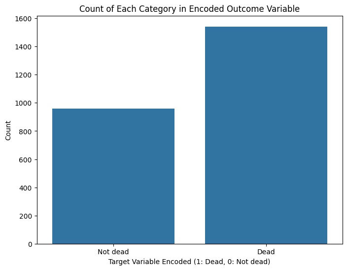

```python
import matplotlib.pyplot as plt
import seaborn as sns

data = pd.read_csv('/content/ARDS-Final_Python_code.csv')


plt.figure(figsize=(8, 6))
sns.countplot(x='Target_variable_encoded', data=data)
plt.title('Count of Each Category in Encoded Outcome Variable')
plt.xlabel('Target Variable Encoded (1: Dead, 0: Not dead)')
plt.ylabel('Count')
plt.xticks([0, 1], ['Not dead', 'Dead'])
plt.show()
```

**4) Basic Data Statistics: Provide core statistics (mean, median, missing value count) for your independent variables and dependent variable.(Target_variable_encoded)**

```python
data = pd.read_csv('/content/ARDS-Final_Python_code.csv')

print("Dataset Columns:", data.columns.tolist())

independent_vars = [
    'age', 'abpd', 'bilirubin_avg', 'lactate_avg', 'glucose_avg',
    'potassium_avg', 'creatinine_avg', 'urine_avg', 'albumin_avg',
    'bun_avg', 'pCO2_avg', 'valvular_disease', 'metastatic_cancer',
    'pt_avg', 'ptt_avg'
]

if 'bmi_mean_imputed' in data.columns:
    independent_vars.append('bmi_mean_imputed')
if 'bmi_median_imputed' in data.columns:
    independent_vars.append('bmi_median_imputed')

dependent_var = 'Target_variable_encoded'

stats = pd.DataFrame({
    'Mean': data[independent_vars].mean(),
    'Median': data[independent_vars].median(),
    'Missing Values': data[independent_vars].isnull().sum()
})

if 'Target_variable_encoded' in data.columns:
    stats_dependent = pd.DataFrame({
        'Mean': [data['Target_variable_encoded'].mean()],
        'Median': [data['Target_variable_encoded'].median()],
        'Missing Values': [data['Target_variable_encoded'].isnull().sum()]
    }, index=['Target_variable_encoded'])

    stats = pd.concat([stats, stats_dependent])

print("Basic Data Statistics for Independent and Outcome Variables:")
print(stats.reset_index().rename(columns={'index': 'Variable'}))

if 'Target_variable_encoded' in data.columns:
    print("\nOutcome Variable Encoding Sample:")
    print(data[[dependent_var, 'Target_variable']].head())
```

```
Dataset Columns: ['SUBJECT_ID', 'Target_variable_encoded', 'Target_variable', 'age', 'INSURANCE', 'bmi_mean_imputed', 'bmi_median_imputed', 'abpd', 'bilirubin_avg', 'lactate_avg', 'glucose_avg', 'potassium_avg', 'creatinine_avg', 'urine_avg', 'albumin_avg', 'bun_avg', 'pCO2_avg', 'valvular_disease',…
Basic Data Statistics for Independent and Outcome Variables:
                   Variable        Mean     Median  Missing Values
0                       age   65.957617  68.000000               0
1                      abpd    0.329825   0.000000               0
2             bilirubin_avg    0.134807   0.019048               0
3               lactate_avg   14.507750   3.873810               0
4               glucose_avg   17.114161  15.368421               0
5             potassium_avg    0.627020   0.548438               0
6            creatinine_avg    0.735462   0.313462               0
7                 urine_avg    0.107800   0.000000               0
8               albumin_avg    0.088416   0.051724               0
9                   bun_avg    4.845672   3.340796               0
10                 pCO2_avg    2.209041   1.385787               0
11         valvular_disease    0.020792   0.000000               0
12        metastatic_cancer    0.020392   0.000000               0
13                   pt_avg   29.427373  25.414286               0
14                  ptt_avg   40.736533  35.150000               0
15         bmi_mean_imputed  111.404706  28.344694               0
16       bmi_median_imputed  111.325057  28.228946               0
17  Target_variable_encoded    0.616553   1.000000               0

Outcome Variable Encoding Sample:
   Target_variable_encoded Target_variable
0                        0        Not dead
1                        0        Not dead
2                        1            Dead
3                        1            Dead
4                        0        Not dead
```

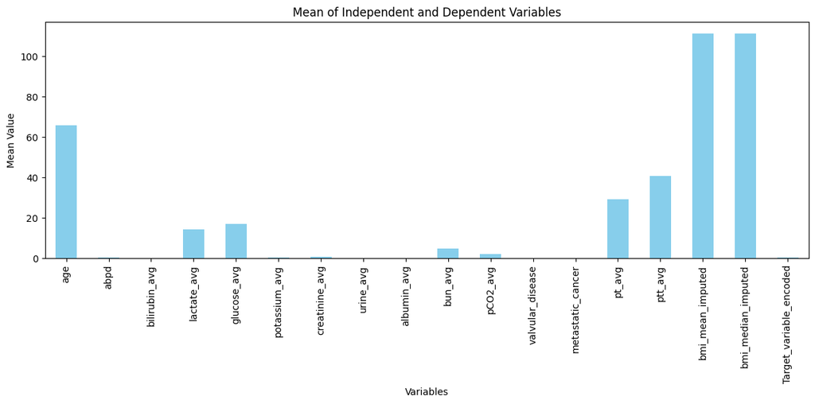

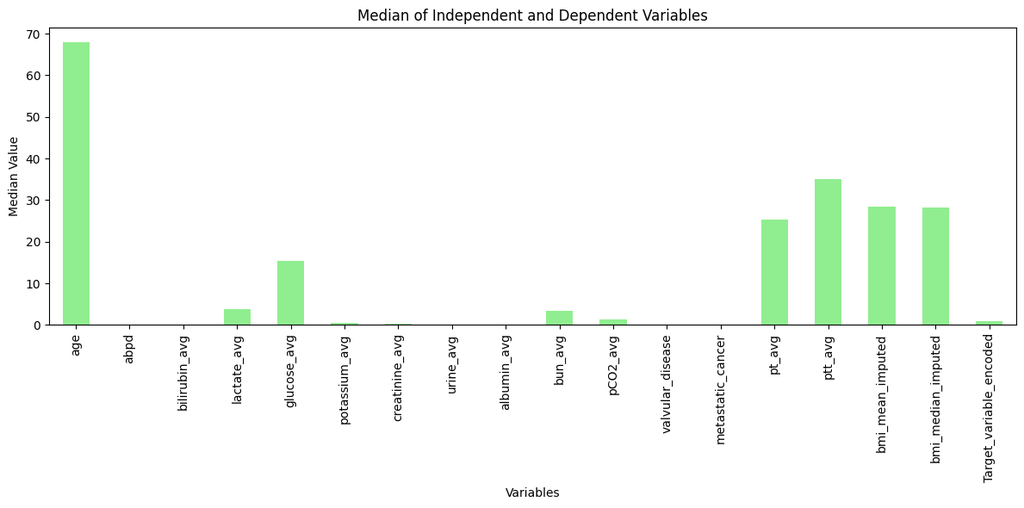

[figure not shown]

```python
# Visualization

plt.figure(figsize=(12, 6))
stats['Mean'].plot(kind='bar', color='skyblue')
plt.title("Mean of Independent and Dependent Variables")
plt.xlabel("Variables")
plt.ylabel("Mean Value")
plt.xticks(rotation=90)
plt.tight_layout()
plt.show()

plt.figure(figsize=(12, 6))
stats['Median'].plot(kind='bar', color='lightgreen')
plt.title("Median of Independent and Dependent Variables")
plt.xlabel("Variables")
plt.ylabel("Median Value")
plt.xticks(rotation=90)
plt.tight_layout()
plt.show()

plt.figure(figsize=(12, 6))
stats['Missing Values'].plot(kind='bar', color='salmon')
plt.title("Missing Values Count for Independent and Dependent Variables")
plt.xlabel("Variables")
plt.ylabel("Missing Value Count")
plt.xticks(rotation=90)
plt.tight_layout()
plt.show()
```

Data Splitting:

Randomly split data into training (70%) and testing (30%) cohorts.

```python
from sklearn.model_selection import train_test_split

file_path = '/content/ARDS-Final_Python_code.csv'
data = pd.read_csv(file_path)

features = [
    'age', 'bmi_mean_imputed', 'bilirubin_avg', 'lactate_avg', 'glucose_avg',
    'potassium_avg', 'creatinine_avg', 'urine_avg', 'albumin_avg', 'bun_avg',
    'pCO2_avg', 'pt_avg', 'ptt_avg', 'valvular_disease', 'metastatic_cancer'
]
target = 'Target_variable_encoded'

X = data[features]
y = data[target]

X_train, X_test, y_train, y_test = train_test_split(
    X, y, test_size=0.3, random_state=42, stratify=y
)

X_train.to_csv('X_train.csv', index=False)
X_test.to_csv('X_test.csv', index=False)
y_train.to_csv('y_train.csv', index=False)
y_test.to_csv('y_test.csv', index=False)

print("Data Splitting Summary:")
print(f"Training Set Size: {len(X_train)}")
print(f"Testing Set Size: {len(X_test)}")
print(f"Training Class Balance:\n{y_train.value_counts(normalize=True)}")
print(f"Testing Class Balance:\n{y_test.value_counts(normalize=True)}")
```

```
Data Splitting Summary:
Training Set Size: 1750
Testing Set Size: 751
Training Class Balance:
Target_variable_encoded
1    0.616571
0    0.383429
Name: proportion, dtype: float64
Testing Class Balance:
Target_variable_encoded
1    0.616511
0    0.383489
Name: proportion, dtype: float64
```

Model Development:

Trained seven machine learning models: Logistic Regression, Random Forest, Naive Bayes, K-Nearest Neighbor (KNN), Support Vector Machine (SVM), Decision Tree, and XGBoost.

Each model was evaluated using the training data.

```python
from sklearn.metrics import (
    accuracy_score, roc_auc_score, confusion_matrix, classification_report
)
from sklearn.linear_model import LogisticRegression
from sklearn.ensemble import RandomForestClassifier
from sklearn.naive_bayes import GaussianNB
from sklearn.neighbors import KNeighborsClassifier
from sklearn.svm import SVC
from sklearn.tree import DecisionTreeClassifier
from xgboost import XGBClassifier
import warnings

warnings.filterwarnings("ignore")

file_path = '/content/ARDS-Final_Python_code.csv'
data = pd.read_csv(file_path)

features = [
    'age', 'bmi_mean_imputed', 'bilirubin_avg', 'lactate_avg', 'glucose_avg',
    'potassium_avg', 'creatinine_avg', 'urine_avg', 'albumin_avg', 'bun_avg',
    'pCO2_avg', 'pt_avg', 'ptt_avg', 'valvular_disease', 'metastatic_cancer'
]
target = 'Target_variable_encoded'

X = data[features]
y = data[target]

X_train, X_test, y_train, y_test = train_test_split(
    X, y, test_size=0.3, random_state=42, stratify=y
)

models = {
    'Logistic Regression': LogisticRegression(max_iter=1000, random_state=42),
    'Random Forest': RandomForestClassifier(n_estimators=100, random_state=42),
    'XGBoost': XGBClassifier(use_label_encoder=False, eval_metric='logloss', random_state=42),
    'Naive Bayes': GaussianNB(),
    'K-Nearest Neighbors': KNeighborsClassifier(n_neighbors=5),
    'Support Vector Machine': SVC(probability=True, random_state=42),
    'Decision Tree': DecisionTreeClassifier(random_state=42)
}

results = []
for model_name, model in models.items():
    model.fit(X_train, y_train)

    y_train_pred = model.predict(X_train)
    y_train_proba = model.predict_proba(X_train)[:, 1] if hasattr(model, "predict_proba") else None

    accuracy = accuracy_score(y_train, y_train_pred)
    auc = roc_auc_score(y_train, y_train_proba) if y_train_proba is not None else "N/A"
    confusion = confusion_matrix(y_train, y_train_pred)
    classification = classification_report(y_train, y_train_pred)

    results.append({
        'Model': model_name,
        'Train Accuracy': accuracy,
        'Train AUC': auc,
        'Confusion Matrix': confusion.tolist(),
        'Classification Report': classification
    })

results_df = pd.DataFrame(results)
for idx, row in results_df.iterrows():
    print(f"\nModel: {row['Model']}")
    print(f"Train Accuracy: {row['Train Accuracy']}")
    print(f"Train AUC: {row['Train AUC']}")
    print("Confusion Matrix:")
    print(row['Confusion Matrix'])
    print("Classification Report:")
    print(row['Classification Report'])

results_df.drop(columns=['Confusion Matrix', 'Classification Report']).to_csv(
    'model_training_metrics.csv', index=False
)
```

```
Model: Logistic Regression
Train Accuracy: 0.72
Train AUC: 0.7834999288682876
Confusion Matrix:
[[374, 297], [193, 886]]
Classification Report:
              precision    recall  f1-score   support

           0       0.66      0.56      0.60       671
           1       0.75      0.82      0.78      1079

    accuracy                           0.72      1750
   macro avg       0.70      0.69      0.69      1750
weighted avg       0.71      0.72      0.71      1750


Model: Random Forest
Train Accuracy: 1.0
Train AUC: 0.9999999999999999
Confusion Matrix:
[[671, 0], [0, 1079]]
Classification Report:
              precision    recall  f1-score   support

           0       1.00      1.00      1.00       671
           1       1.00      1.00      1.00      1079

    accuracy                           1.00      1750
   macro avg       1.00      1.00      1.00      1750
weighted avg       1.00      1.00      1.00      1750


Model: XGBoost
Train Accuracy: 1.0
Train AUC: 1.0
Confusion Matrix:
[[671, 0], [0, 1079]]
Classification Report:
              precision    recall  f1-score   support

```

[output cut: 55 more lines]

```

Model: Decision Tree
Train Accuracy: 1.0
Train AUC: 1.0
Confusion Matrix:
[[671, 0], [0, 1079]]
Classification Report:
              precision    recall  f1-score   support

           0       1.00      1.00      1.00       671
           1       1.00      1.00      1.00      1079

    accuracy                           1.00      1750
   macro avg       1.00      1.00      1.00      1750
weighted avg       1.00      1.00      1.00      1750
```

Model Evaluation:

Performance metrics included AUC (Area Under the Curve), accuracy, sensitivity, specificity, positive predictive value (PPV), and negative predictive value (NPV).

```python
def calculate_metrics(y_true, y_pred):
    tn, fp, fn, tp = confusion_matrix(y_true, y_pred).ravel()
    sensitivity = tp / (tp + fn)
    specificity = tn / (tn + fp)
    ppv = tp / (tp + fp)
    npv = tn / (tn + fn)
    return sensitivity, specificity, ppv, npv

results = []
for model_name, model in models.items():

    model.fit(X_train, y_train)

    y_train_pred = model.predict(X_train)
    y_train_proba = model.predict_proba(X_train)[:, 1] if hasattr(model, "predict_proba") else None

    y_test_pred = model.predict(X_test)
    y_test_proba = model.predict_proba(X_test)[:, 1] if hasattr(model, "predict_proba") else None

    train_accuracy = accuracy_score(y_train, y_train_pred)
    train_auc = roc_auc_score(y_train, y_train_proba) if y_train_proba is not None else "N/A"
    train_sensitivity, train_specificity, train_ppv, train_npv = calculate_metrics(y_train, y_train_pred)

    test_accuracy = accuracy_score(y_test, y_test_pred)
    test_auc = roc_auc_score(y_test, y_test_proba) if y_test_proba is not None else "N/A"
    test_sensitivity, test_specificity, test_ppv, test_npv = calculate_metrics(y_test, y_test_pred)

    results.append({
        'Model': model_name,
        'Train Accuracy': train_accuracy,
        'Test Accuracy': test_accuracy,
        'Train AUC': train_auc,
        'Test AUC': test_auc,
        'Train Sensitivity': train_sensitivity,
        'Test Sensitivity': test_sensitivity,
        'Train Specificity': train_specificity,
        'Test Specificity': test_specificity,
        'Train PPV': train_ppv,
        'Test PPV': test_ppv,
        'Train NPV': train_npv,
        'Test NPV': test_npv
    })

results_df = pd.DataFrame(results)

results_file = 'train_test_evaluation_metrics.csv'
results_df.to_csv(results_file, index=False)
print(f"Results saved to {results_file}")

print("Train and Test Evaluation Metrics:")
print(results_df)
```

```
Results saved to train_test_evaluation_metrics.csv
Train and Test Evaluation Metrics:
                    Model  Train Accuracy  Test Accuracy  Train AUC  Test AUC  \
0     Logistic Regression        0.720000       0.700399   0.783500  0.748830
1           Random Forest        1.000000       0.703063   1.000000  0.741559
2                 XGBoost        1.000000       0.697736   1.000000  0.741526
3             Naive Bayes        0.683429       0.661784   0.740723  0.695719
4     K-Nearest Neighbors        0.770286       0.657790   0.840191  0.692397
5  Support Vector Machine        0.617143       0.616511   0.734027  0.698907
6           Decision Tree        1.000000       0.653795   1.000000  0.639166

   Train Sensitivity  Test Sensitivity  Train Specificity  Test Specificity  \
0           0.821131          0.805616           0.557377          0.531250
1           1.000000          0.796976           1.000000          0.552083
2           1.000000          0.796976           1.000000          0.538194
3           0.917516          0.896328           0.307004          0.284722
4           0.846154          0.753780           0.648286          0.503472
5           1.000000          1.000000           0.001490          0.000000
6           1.000000          0.701944           1.000000          0.576389

   Train PPV  Test PPV  Train NPV  Test NPV
0   0.748943  0.734252   0.659612  0.629630
1   1.000000  0.740964   1.000000  0.628458
2   1.000000  0.735060   1.000000  0.622490
3   0.680412  0.668277   0.698305  0.630769
4   0.794604  0.709350   0.723794  0.559846
5   0.616924  0.616511   1.000000       NaN
6   1.000000  0.727069   1.000000  0.546053
```

Feature Importance Analysis:

Highlighted the importance of key predictors

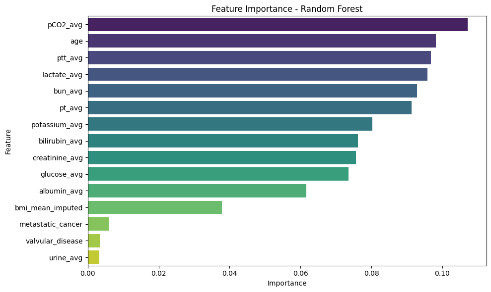

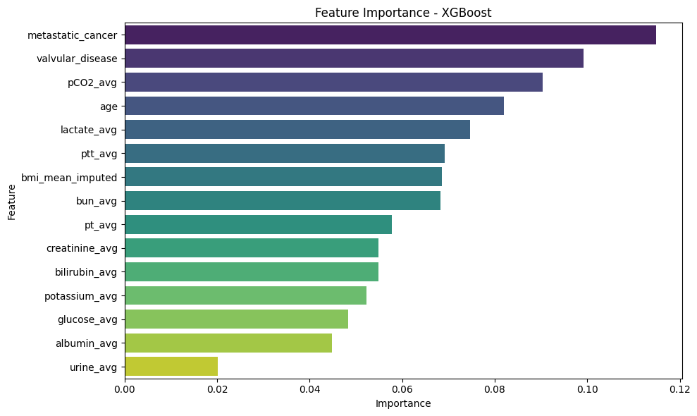

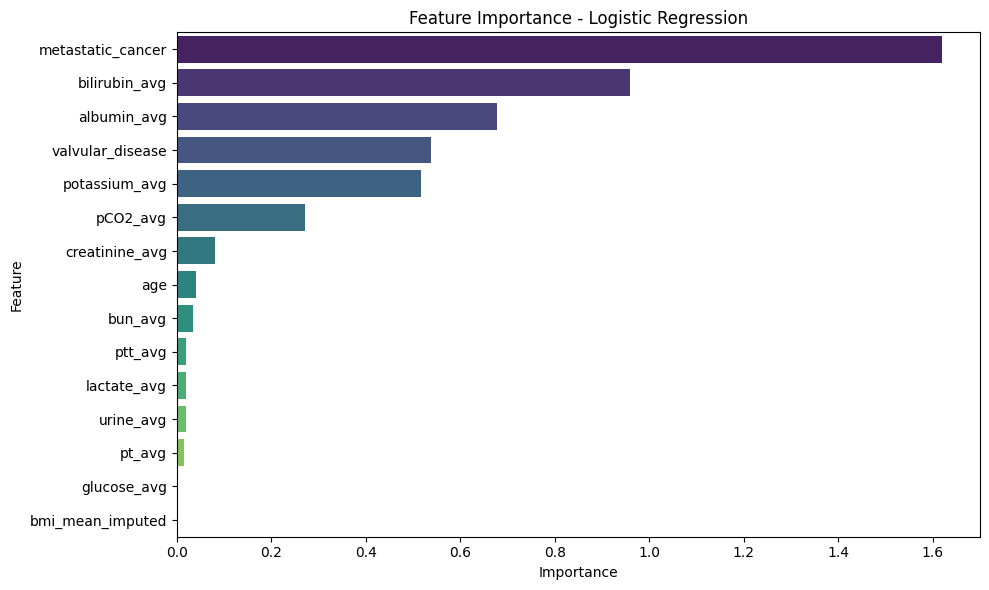

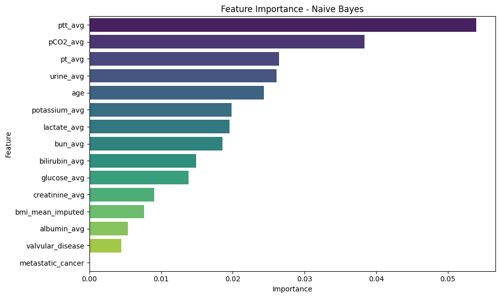

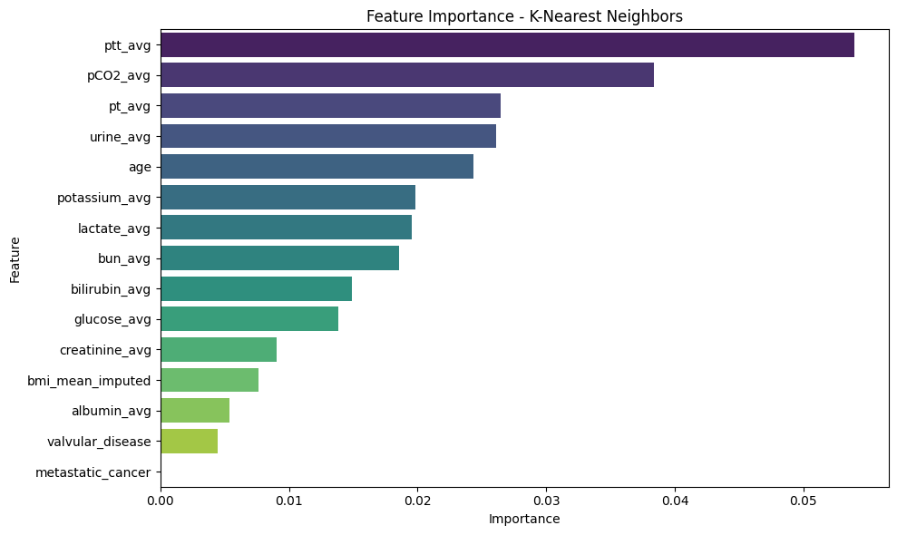

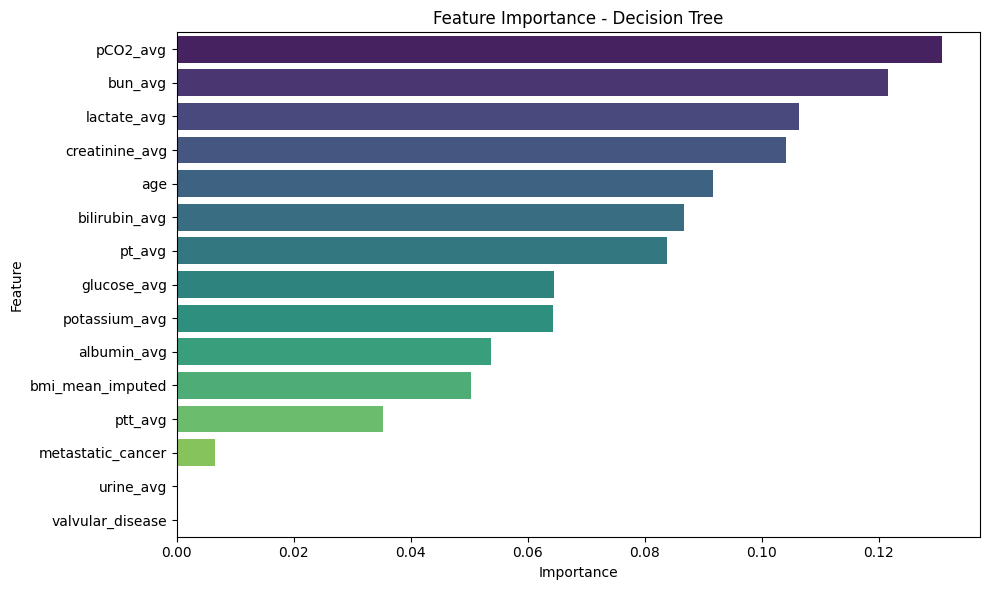

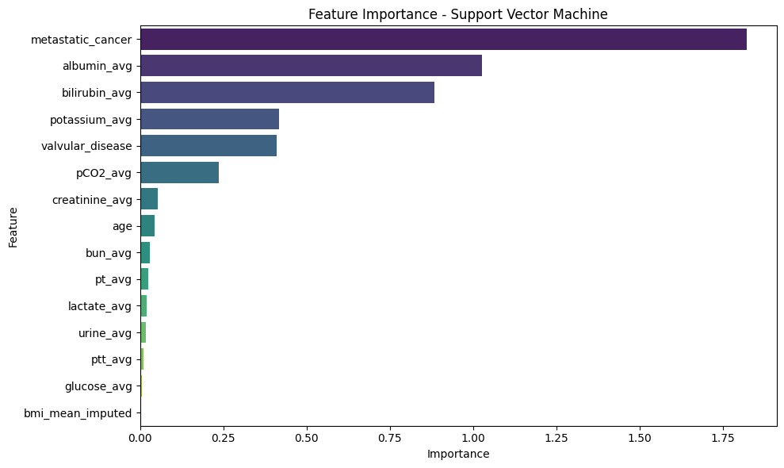

```
Top Features from Random Forest:
        Feature  Importance
10     pCO2_avg    0.107124
0           age    0.098157
12      ptt_avg    0.096834
3   lactate_avg    0.095842
9       bun_avg    0.092872

Top Features from XGBoost:
              Feature  Importance
14  metastatic_cancer    0.114839
13   valvular_disease    0.099145
10           pCO2_avg    0.090298
0                 age    0.082030
3         lactate_avg    0.074711

Top Features from Logistic Regression:
              Feature  Importance
14  metastatic_cancer    1.619390
2       bilirubin_avg    0.959460
8         albumin_avg    0.678158
13   valvular_disease    0.539185
5       potassium_avg    0.517060

Top Features from Naive Bayes:
      Feature  Importance
12    ptt_avg    0.053951
10   pCO2_avg    0.038352
11     pt_avg    0.026495
7   urine_avg    0.026112
0         age    0.024321

Top Features from K-Nearest Neighbors:
      Feature  Importance
12    ptt_avg    0.053951
10   pCO2_avg    0.038352
11     pt_avg    0.026495
7   urine_avg    0.026112
0         age    0.024321

Top Features from Decision Tree:
           Feature  Importance
10        pCO2_avg    0.130802
9          bun_avg    0.121556
3      lactate_avg    0.106410
6   creatinine_avg    0.104255
0              age    0.091761

Top Features from Support Vector Machine:
              Feature  Importance
14  metastatic_cancer    1.821527
8         albumin_avg    1.026239
2       bilirubin_avg    0.884858
5       potassium_avg    0.417656
13   valvular_disease    0.410720
```

```python
from sklearn.feature_selection import mutual_info_classif

def plot_importance(importance_df, model_name):
    plt.figure(figsize=(10, 6))
    sns.barplot(x='Importance', y='Feature', data=importance_df, palette='viridis')
    plt.title(f'Feature Importance - {model_name}')
    plt.xlabel('Importance')
    plt.ylabel('Feature')
    plt.tight_layout()
    plt.show()

# 1. Random Forest
rf_model = RandomForestClassifier(n_estimators=100, random_state=42)
rf_model.fit(X_train, y_train)
rf_importances = rf_model.feature_importances_
rf_importance_df = pd.DataFrame({
    'Feature': features,
    'Importance': rf_importances
}).sort_values(by='Importance', ascending=False)
plot_importance(rf_importance_df, 'Random Forest')

# 2. XGBoost
xgb_model = XGBClassifier(use_label_encoder=False, eval_metric='logloss', random_state=42)
xgb_model.fit(X_train, y_train)
xgb_importances = xgb_model.feature_importances_
xgb_importance_df = pd.DataFrame({
    'Feature': features,
    'Importance': xgb_importances
}).sort_values(by='Importance', ascending=False)
plot_importance(xgb_importance_df, 'XGBoost')

# 3. Logistic Regression
logreg_model = LogisticRegression(max_iter=1000, random_state=42)
logreg_model.fit(X_train, y_train)
logreg_coefficients = logreg_model.coef_[0]
logreg_importance_df = pd.DataFrame({
    'Feature': features,
    'Importance': np.abs(logreg_coefficients)
}).sort_values(by='Importance', ascending=False)
plot_importance(logreg_importance_df, 'Logistic Regression')

# 4. Naive Bayes (GaussianNB)
nb_model = GaussianNB()
nb_model.fit(X_train, y_train)
nb_importances = mutual_info_classif(X_train, y_train, random_state=42)
nb_importance_df = pd.DataFrame({
    'Feature': features,
    'Importance': nb_importances
}).sort_values(by='Importance', ascending=False)
plot_importance(nb_importance_df, 'Naive Bayes')

# 5. K-Nearest Neighbors (KNN)
knn_model = KNeighborsClassifier(n_neighbors=5)
knn_model.fit(X_train, y_train)
knn_importances = mutual_info_classif(X_train, y_train, random_state=42)
knn_importance_df = pd.DataFrame({
    'Feature': features,
    'Importance': knn_importances
}).sort_values(by='Importance', ascending=False)
plot_importance(knn_importance_df, 'K-Nearest Neighbors')

# 6. Decision Tree
dt_model = DecisionTreeClassifier(random_state=42)
dt_model.fit(X_train, y_train)
dt_importances = dt_model.feature_importances_
dt_importance_df = pd.DataFrame({
    'Feature': features,
    'Importance': dt_importances
}).sort_values(by='Importance', ascending=False)
plot_importance(dt_importance_df, 'Decision Tree')

# 7. Support Vector Machine (SVM)
svm_model = SVC(kernel='linear', random_state=42)
svm_model.fit(X_train, y_train)
svm_coefficients = np.abs(svm_model.coef_[0])
svm_importance_df = pd.DataFrame({
    'Feature': features,
    'Importance': svm_coefficients
}).sort_values(by='Importance', ascending=False)
plot_importance(svm_importance_df, 'Support Vector Machine')

print("\nTop Features from Random Forest:")
print(rf_importance_df.head())

print("\nTop Features from XGBoost:")
print(xgb_importance_df.head())

print("\nTop Features from Logistic Regression:")
print(logreg_importance_df.head())

print("\nTop Features from Naive Bayes:")
print(nb_importance_df.head())

print("\nTop Features from K-Nearest Neighbors:")
print(knn_importance_df.head())

print("\nTop Features from Decision Tree:")
print(dt_importance_df.head())

print("\nTop Features from Support Vector Machine:")
print(svm_importance_df.head())
```

Model Validation and Comparison:

Assessed model performance using metrics across both training and testing datasets. Conducted receiver operating characteristic (ROC) curve analysis for visual comparison.

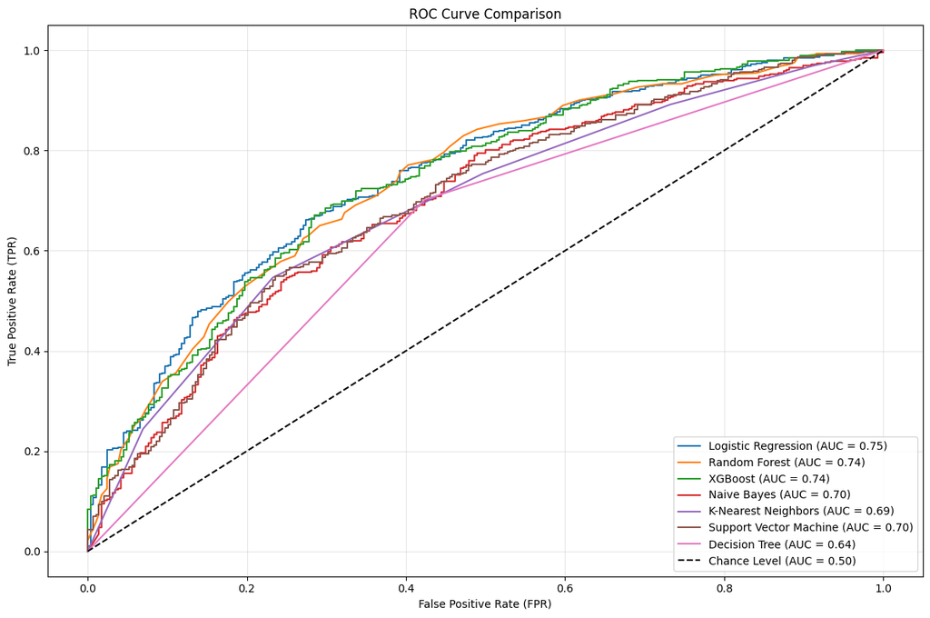

```
Results saved to /content/model_validation_metrics.csv
Model Validation Metrics:
                    Model  Train Accuracy  Test Accuracy  Train AUC  Test AUC
0     Logistic Regression        0.720000       0.700399   0.783500  0.748830
1           Random Forest        1.000000       0.703063   1.000000  0.741559
2                 XGBoost        1.000000       0.697736   1.000000  0.741526
3             Naive Bayes        0.683429       0.661784   0.740723  0.695719
4     K-Nearest Neighbors        0.770286       0.657790   0.840191  0.692397
5  Support Vector Machine        0.617143       0.616511   0.734027  0.698907
6           Decision Tree        1.000000       0.653795   1.000000  0.639166
```

```python
from sklearn.metrics import (
    roc_auc_score, roc_curve, accuracy_score, confusion_matrix
)

roc_data = []
results = []
plt.figure(figsize=(12, 8))

for model_name, model in models.items():

    model.fit(X_train, y_train)

    y_train_pred = model.predict(X_train)
    y_train_proba = model.predict_proba(X_train)[:, 1] if hasattr(model, "predict_proba") else None

    y_test_pred = model.predict(X_test)
    y_test_proba = model.predict_proba(X_test)[:, 1] if hasattr(model, "predict_proba") else None

    train_accuracy = accuracy_score(y_train, y_train_pred)
    test_accuracy = accuracy_score(y_test, y_test_pred)
    train_auc = roc_auc_score(y_train, y_train_proba) if y_train_proba is not None else "N/A"
    test_auc = roc_auc_score(y_test, y_test_proba) if y_test_proba is not None else "N/A"

    if y_test_proba is not None:
        fpr, tpr, _ = roc_curve(y_test, y_test_proba)
        roc_auc = roc_auc_score(y_test, y_test_proba)
        roc_data.append((model_name, fpr, tpr, roc_auc))
        plt.plot(fpr, tpr, label=f'{model_name} (AUC = {roc_auc:.2f})')

    results.append({
        'Model': model_name,
        'Train Accuracy': train_accuracy,
        'Test Accuracy': test_accuracy,
        'Train AUC': train_auc,
        'Test AUC': test_auc
    })

plt.plot([0, 1], [0, 1], 'k--', label='Chance Level (AUC = 0.50)')
plt.title('ROC Curve Comparison')
plt.xlabel('False Positive Rate (FPR)')
plt.ylabel('True Positive Rate (TPR)')
plt.legend(loc='lower right')
plt.grid(alpha=0.3)
plt.tight_layout()
plt.show()

results_df = pd.DataFrame(results)

results_file = '/content/model_validation_metrics.csv'
results_df.to_csv(results_file, index=False)
print(f"Results saved to {results_file}")

print("Model Validation Metrics:")
print(results_df)
```

```
Recall and Precision Summary:
                 Model  Custom Recall (0.5)  Custom Precision (0.5)
0  Logistic Regression             0.805616                0.734252
1        Random Forest             0.807775                0.740594
2              XGBoost             0.796976                0.735060
3          Naive Bayes             0.896328                0.668277
4  K-Nearest Neighbors             0.753780                0.709350
5        Decision Tree             0.701944                0.727069
Recall and Precision data saved to /content/recall_precision_metrics_with_graph.csv
```

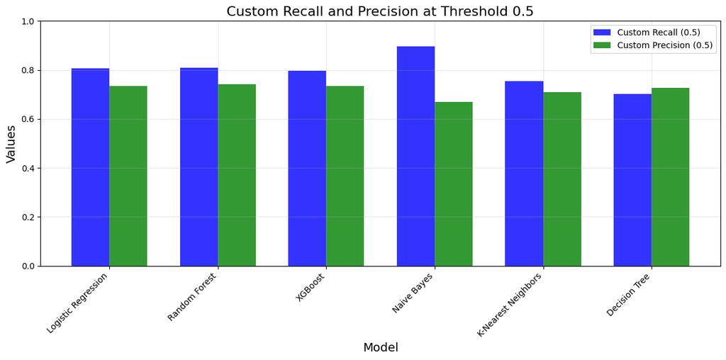

```python
from sklearn.metrics import precision_recall_curve
import numpy as np

models = {
    'Logistic Regression': LogisticRegression(max_iter=1000, random_state=42),
    'Random Forest': RandomForestClassifier(n_estimators=100, random_state=42),
    'XGBoost': XGBClassifier(use_label_encoder=False, eval_metric='logloss', random_state=42),
    'Naive Bayes': GaussianNB(),
    'K-Nearest Neighbors': KNeighborsClassifier(n_neighbors=5),
    'Decision Tree': DecisionTreeClassifier(random_state=42)
}

recall_data = []

plt.figure(figsize=(12, 8))

for model_name, model in models.items():
    model.fit(X_train, y_train)

    y_test_proba = model.predict_proba(X_test)[:, 1] if hasattr(model, "predict_proba") else None

    if y_test_proba is not None:
        precision, recall, thresholds = precision_recall_curve(y_test, y_test_proba)


        threshold = 0.5
        y_test_pred_custom = (y_test_proba >= threshold).astype(int)
        tp = np.sum((y_test_pred_custom == 1) & (y_test == 1))
        fp = np.sum((y_test_pred_custom == 1) & (y_test == 0))
        fn = np.sum((y_test_pred_custom == 0) & (y_test == 1))
        precision_custom = tp / (tp + fp) if (tp + fp) > 0 else 0
        recall_custom = tp / (tp + fn) if (tp + fn) > 0 else 0


        recall_data.append({
            'Model': model_name,
            'Custom Recall (0.5)': recall_custom,
            'Custom Precision (0.5)': precision_custom
        })
    else:
        print(f"{model_name} does not support probability predictions.")

recall_df = pd.DataFrame(recall_data)
print("\nRecall and Precision Summary:")
print(recall_df)

recall_file = '/content/recall_precision_metrics_with_graph.csv'
recall_df.to_csv(recall_file, index=False)
print(f"Recall and Precision data saved to {recall_file}")

fig, ax = plt.subplots(figsize=(12, 6))

bar_width = 0.35
positions = np.arange(len(recall_df['Model']))

ax.bar(positions, recall_df['Custom Recall (0.5)'], bar_width, label='Custom Recall (0.5)', alpha=0.8, color='blue')
ax.bar(
    positions + bar_width,
    recall_df['Custom Precision (0.5)'],
    bar_width,
    label='Custom Precision (0.5)',
    alpha=0.8,
    color='green'
)

ax.set_title('Custom Recall and Precision at Threshold 0.5', fontsize=16)
ax.set_xlabel('Model', fontsize=14)
ax.set_ylabel('Values', fontsize=14)
ax.set_xticks(positions + bar_width / 2)
ax.set_xticklabels(recall_df['Model'], rotation=45, ha='right')
ax.set_ylim([0, 1])
ax.legend()
plt.grid(alpha=0.3)
plt.tight_layout()

plt.show()
```

```python
!jupyter nbconvert --to html /content/Sepsis_ARDS.ipynb
```

```
[NbConvertApp] Converting notebook /content/Sepsis_ARDS.ipynb to html
[NbConvertApp] WARNING | Alternative text is missing on 16 image(s).
[NbConvertApp] Writing 1519772 bytes to /content/Sepsis_ARDS.html
```